# Homework 2

Mutua Fadhla Mohamed

# Quantitativo

## Impostazioni progetto

```r
library(ggplot2)

plot_theme = theme_minimal() +
    theme(
        plot.title = element_text(face = "bold", hjust = 0.5),
        plot.subtitle = element_text(hjust = 0.5),
        axis.line = element_line(color = "darkgrey", size = 0.4),
        axis.ticks = element_line(color = "black"))
theme_set(plot_theme)
```

## Lettura dati

```r
House_prices = read.csv2("./house_price.csv", sep = ",", stringsAsFactors=T, row.names=1)
```

## Scelta di colonne

```r
column_selection <- function(data){
  House_prices_numeric_bool = sapply(data, is.numeric)
  House_prices_numeric_fcolnames = names(data[House_prices_numeric_bool])
  # Rimozione delle colonne
  House_prices_numeric_fcolnames = House_prices_numeric_fcolnames[c(-1,-4,-5)]
  print("Colonne scelte: ")
  print(House_prices_numeric_fcolnames)
  return(House_prices_numeric_fcolnames)
}
House_prices_numeric_colnames = column_selection(House_prices)
```

```
## [1] "Colonne scelte: "
##  [1] "LotFrontage"   "LotArea"       "YearBuilt"     "YearRemodAdd"
##  [5] "MasVnrArea"    "BsmtFinSF1"    "BsmtFinSF2"    "BsmtUnfSF"
##  [9] "TotalBsmtSF"   "X1stFlrSF"     "X2ndFlrSF"     "LowQualFinSF"
## [13] "GrLivArea"     "BsmtFullBath"  "BsmtHalfBath"  "FullBath"
## [17] "HalfBath"      "BedroomAbvGr"  "KitchenAbvGr"  "TotRmsAbvGrd"
## [21] "Fireplaces"    "GarageYrBlt"   "GarageCars"    "GarageArea"
## [25] "WoodDeckSF"    "OpenPorchSF"   "EnclosedPorch" "X3SsnPorch"
## [29] "ScreenPorch"   "PoolArea"      "MiscVal"       "MoSold"
## [33] "YrSold"        "SalePrice"
```

## Analisi Primaria

```r
Analisi_Primaria <- function(data){
  print(paste("Numeri di osservazione: ",nrow(House_prices)))
  print(paste("Numeri di variabili: ",length(data)))
}
Analisi_Primaria(House_prices_numeric_colnames)
```

```
## [1] "Numeri di osservazione:  1460"
## [1] "Numeri di variabili:  34"
```

## Analisi Univariata

```r
univariate_analysis <- function(data, colname) {
  result = list()

  result[[colname]] = list(
    # Summary statistics including min, 1st and 3rd quartile, mean, median, max
    Summary = summary(data),
    # Variance
    Variance = round(var(data), 2),
    # Standard Deviation
    Standard_Deviation = round(sd(data), 2),
    # Mode calculation
    Moda = Mode(data)
  )
  return(result)
}

Mode <- function(data) {
  uniq_vals = unique(data)
  tab = tabulate(match(data, uniq_vals))
  modes = uniq_vals[tab == max(tab)]
  list(Mode = modes, Frequency = max(tab))
}

sum_info_h = lapply(House_prices_numeric_colnames, function(ele) {
  colummn = na.omit(House_prices[, ele])
  univariate_analysis(colummn, ele)
})
```

## Funzione di Visualizazione continuo

```r
visualization_continuos <- function(data,sumary,colname){
  par(mfrow = c(2,2))
  print(sumary)
  boxplot(data, horizontal = T, main = paste("Boxplot of ", colname))
  hist(data, probability = F, col = 2, main = paste("Hist of ", colname))
  curve(dnorm(x, mean = mean(data), sd = sd(data)),
        add=T, col = 4)
  print(density(data))
  plot(density(data), main = paste("Desnity Distribution of ", colname))
  qqnorm(data, col = 3, main = paste("QQnorm of ", colname))
  qqline(data, col = 5, pch = 10)
}
```

## Funzione di Visualizazione discreta

```r
visualization_discrete <- function(data,sumary,colname){
  par(mfrow = c(1,1))
  print(sumary)
  print("freq: ")
  cat("\n")
  print(table(data))
  cat("\n")
  print("percintile: ")
  cat("\n")
  print(prop.table(table(data))*100)
  cat("\n")
  barplot(table(data), col = 2, main = paste("Barplot of ", colname))
}
```

## Rimozione 0

```r
rm_0 <- function(data){
  imp_data = data
  imp_data[imp_data == 0] = NA
  imp_data = na.omit(imp_data)
  return(imp_data)
}
```

## Rimozione degli outlier attraverso intervallo di confidenza

```r
rm_oultiers <- function(data, CI){
  mean_data = mean(data)
  sd_data = sd(data)
  confidence_level = CI
  z_score = qnorm((1 + confidence_level) / 2)

  lower_bound = mean_data - z_score * sd_data
  upper_bound = mean_data + z_score * sd_data

  data_in_ci = data[data >= lower_bound & data <= upper_bound]
  return(data_in_ci)
}
```

### 1: Visualizazione LotFrontage

```r
visualization_continuos(na.omit(House_prices[,"LotFrontage"]), sum_info_h[1],"LotFrontage")
```

```
## [[1]]
## [[1]]$LotFrontage
## [[1]]$LotFrontage$Summary
##    Min. 1st Qu.  Median    Mean 3rd Qu.    Max.
##   21.00   59.00   69.00   70.05   80.00  313.00
##
## [[1]]$LotFrontage$Variance
## [1] 589.75
##
## [[1]]$LotFrontage$Standard_Deviation
## [1] 24.28
##
## [[1]]$LotFrontage$Moda
## [[1]]$LotFrontage$Moda$Mode
## [1] 60
##
## [[1]]$LotFrontage$Moda$Frequency
## [1] 143
```

```
##
## Call:
##  density.default(x = data)
##
## Data: data (1201 obs.);  Bandwidth 'bw' = 3.415
##
##        x                y
##  Min.   : 10.75   Min.   :0.0000000
##  1st Qu.: 88.88   1st Qu.:0.0000000
##  Median :167.00   Median :0.0001649
##  Mean   :167.00   Mean   :0.0031969
##  3rd Qu.:245.12   3rd Qu.:0.0032738
##  Max.   :323.25   Max.   :0.0238537
```

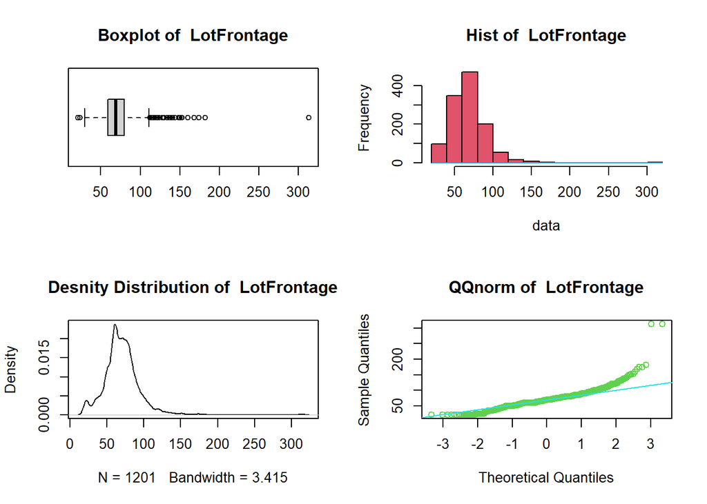

Possiamo dedurre che la distribuzione è positivamente asimetrica e che la maggior parte degli lotti ha un percorso verso la strada compreso tra 59 e 80 piedi, essendo rispettivamente il 1° e il 3° quantile e maggiormente alineati alla retta qq della norma. Rimangono ancora degli outlier

## Rimozione

```r
rm_outlier_data = rm_oultiers(na.omit(House_prices[,"LotFrontage"]),.90)
visualization_continuos(rm_outlier_data, univariate_analysis(rm_outlier_data,"LotFrontage"),"LotFrontage")
```

```
## $LotFrontage
## $LotFrontage$Summary
##    Min. 1st Qu.  Median    Mean 3rd Qu.    Max.
##   32.00   60.00   69.00   68.91   80.00  109.00
##
## $LotFrontage$Variance
## [1] 261.63
##
## $LotFrontage$Standard_Deviation
## [1] 16.17
##
## $LotFrontage$Moda
## $LotFrontage$Moda$Mode
## [1] 60
##
## $LotFrontage$Moda$Frequency
## [1] 143
```

```
##
## Call:
##  density.default(x = data)
##
## Data: data (1100 obs.);  Bandwidth 'bw' = 3.31
##
##        x                y
##  Min.   : 22.07   Min.   :5.250e-06
##  1st Qu.: 46.28   1st Qu.:3.296e-03
##  Median : 70.50   Median :7.436e-03
##  Mean   : 70.50   Mean   :1.031e-02
##  3rd Qu.: 94.72   3rd Qu.:1.884e-02
##  Max.   :118.93   Max.   :2.641e-02
```

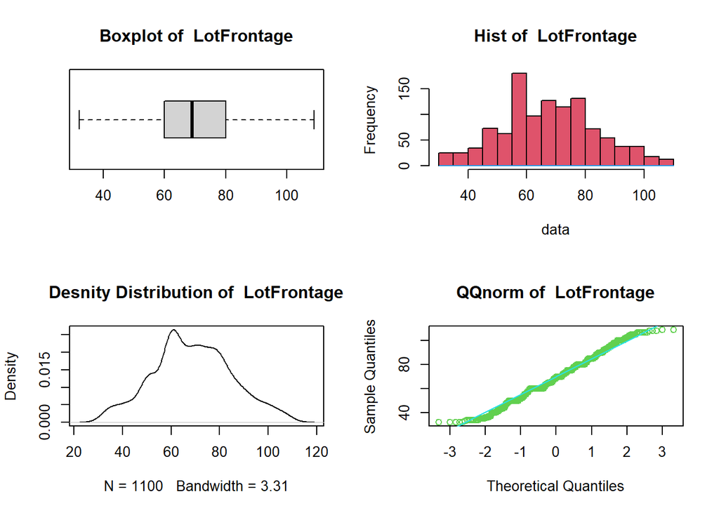

Possiamo osservare che la distribuzione segue per lo piu quella gaussiana e che la maggior parte degli lotti ha un percorso verso la strada compreso tra 60 e 80 piedi, essendo rispettivamente il 1° e il 3° quantile e con maggior densita alineati alla retta qq della norma.

### 2: Visualizazione LotArea

```r
visualization_continuos(na.omit(House_prices[,"LotArea"]), sum_info_h[2],"LotArea")
```

```
## [[1]]
## [[1]]$LotArea
## [[1]]$LotArea$Summary
##    Min. 1st Qu.  Median    Mean 3rd Qu.    Max.
##    1300    7554    9478   10517   11602  215245
##
## [[1]]$LotArea$Variance
## [1] 99625650
##
## [[1]]$LotArea$Standard_Deviation
## [1] 9981.26
##
## [[1]]$LotArea$Moda
## [[1]]$LotArea$Moda$Mode
## [1] 7200
##
## [[1]]$LotArea$Moda$Frequency
## [1] 25
```

```
##
## Call:
##  density.default(x = data)
##
## Data: data (1460 obs.);  Bandwidth 'bw' = 633.2
##
##        x                  y
##  Min.   :  -599.5   Min.   :0.000e+00
##  1st Qu.: 53836.5   1st Qu.:0.000e+00
##  Median :108272.5   Median :0.000e+00
##  Mean   :108272.5   Mean   :4.587e-06
##  3rd Qu.:162708.5   3rd Qu.:2.697e-07
##  Max.   :217144.5   Max.   :1.404e-04
```

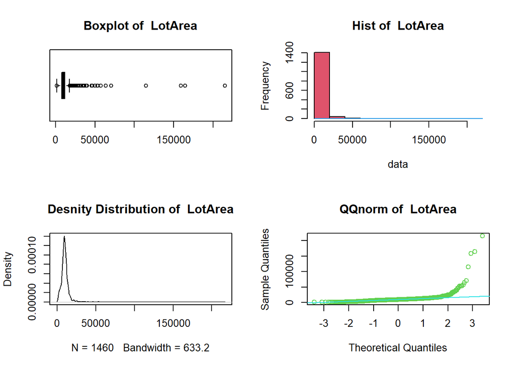

Possiamo dedurre che la distribuzione è positivamente asimetrica e che la maggior parte degli lotti ha un area compreso tra 7554 e 11602 piedi^2, essendo rispettivamente il 1° e il 3° quantile e e con maggior densita alineati alla retta qq della norma. Rimangono ancora degli outlier

## Rimozione

```r
rm_outlier_data = rm_oultiers(na.omit(House_prices[,"LotArea"]),.50)
visualization_continuos(rm_outlier_data, univariate_analysis(rm_outlier_data,"LotArea"),"LotArea")
```

```
## $LotArea
## $LotArea$Summary
##    Min. 1st Qu.  Median    Mean 3rd Qu.    Max.
##    3842    7877    9505    9666   11325   17217
##
## $LotArea$Variance
## [1] 7453350
##
## $LotArea$Standard_Deviation
## [1] 2730.08
##
## $LotArea$Moda
## $LotArea$Moda$Mode
## [1] 7200
##
## $LotArea$Moda$Frequency
## [1] 25
```

```
##
## Call:
##  density.default(x = data)
##
## Data: data (1299 obs.);  Bandwidth 'bw' = 552.1
##
##        x               y
##  Min.   : 2186   Min.   :2.276e-08
##  1st Qu.: 6358   1st Qu.:1.739e-05
##  Median :10530   Median :4.514e-05
##  Mean   :10530   Mean   :5.987e-05
##  3rd Qu.:14701   3rd Qu.:1.008e-04
##  Max.   :18873   Max.   :1.621e-04
```

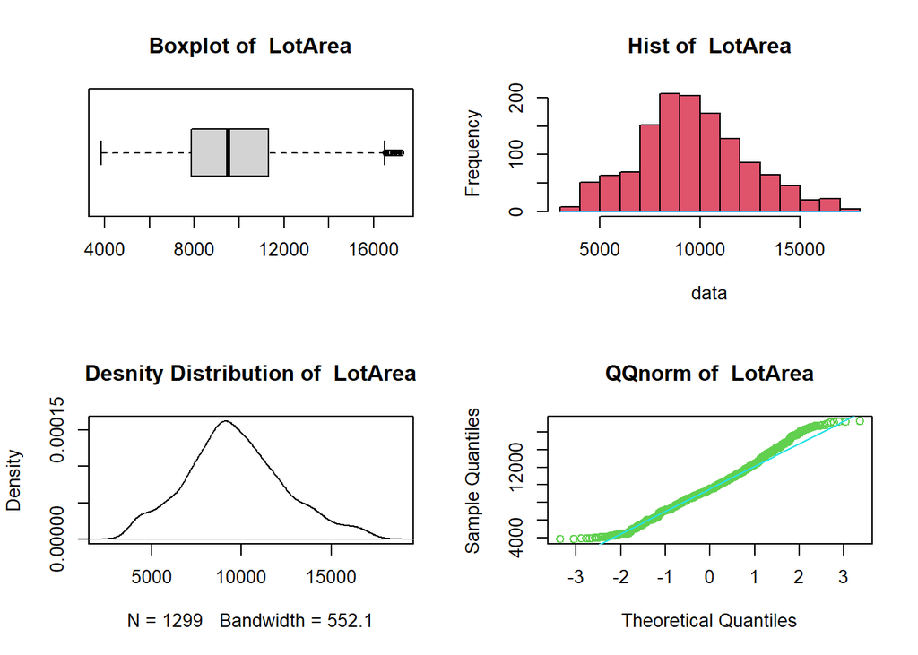

### 3: Visualizazione YearBuilt

```r
visualization_continuos(na.omit(House_prices[,"YearBuilt"]), sum_info_h[3],"YearBuilt")
```

```
## [[1]]
## [[1]]$YearBuilt
## [[1]]$YearBuilt$Summary
##    Min. 1st Qu.  Median    Mean 3rd Qu.    Max.
##    1872    1954    1973    1971    2000    2010
##
## [[1]]$YearBuilt$Variance
## [1] 912.22
##
## [[1]]$YearBuilt$Standard_Deviation
## [1] 30.2
##
## [[1]]$YearBuilt$Moda
## [[1]]$YearBuilt$Moda$Mode
## [1] 2006
##
## [[1]]$YearBuilt$Moda$Frequency
## [1] 67
```

```
##
## Call:
##  density.default(x = data)
##
## Data: data (1460 obs.);  Bandwidth 'bw' = 6.33
##
##        x              y
##  Min.   :1853   Min.   :6.120e-07
##  1st Qu.:1897   1st Qu.:5.052e-04
##  Median :1941   Median :4.774e-03
##  Mean   :1941   Mean   :5.677e-03
##  3rd Qu.:1985   3rd Qu.:9.652e-03
##  Max.   :2029   Max.   :1.871e-02
```

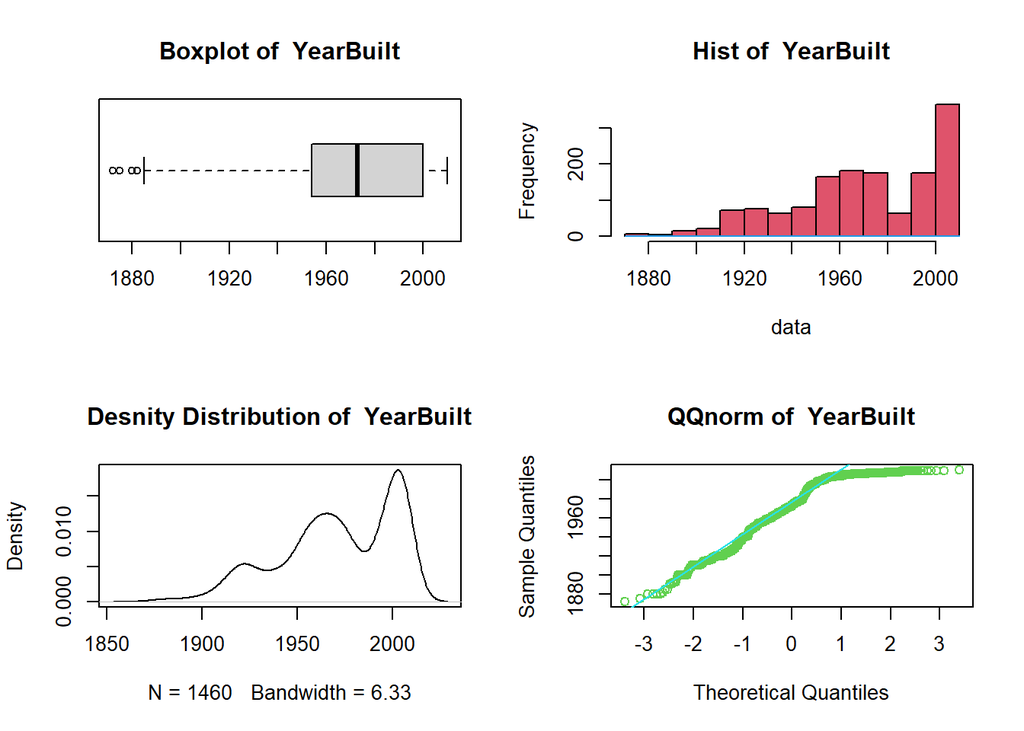

### 4: Visualizazione YearRemodAd

```r
visualization_continuos(na.omit(House_prices[,"YearRemodAdd"]), sum_info_h[4], "YearBuilt")
```

```
## [[1]]
## [[1]]$YearRemodAdd
## [[1]]$YearRemodAdd$Summary
##    Min. 1st Qu.  Median    Mean 3rd Qu.    Max.
##    1950    1967    1994    1985    2004    2010
##
## [[1]]$YearRemodAdd$Variance
## [1] 426.23
##
## [[1]]$YearRemodAdd$Standard_Deviation
## [1] 20.65
##
## [[1]]$YearRemodAdd$Moda
## [[1]]$YearRemodAdd$Moda$Mode
## [1] 1950
##
## [[1]]$YearRemodAdd$Moda$Frequency
## [1] 178
```

```
##
## Call:
##  density.default(x = data)
##
## Data: data (1460 obs.);  Bandwidth 'bw' = 4.327
##
##        x              y
##  Min.   :1937   Min.   :2.807e-05
##  1st Qu.:1959   1st Qu.:7.214e-03
##  Median :1980   Median :1.023e-02
##  Mean   :1980   Mean   :1.162e-02
##  3rd Qu.:2001   3rd Qu.:1.389e-02
##  Max.   :2023   Max.   :3.250e-02
```

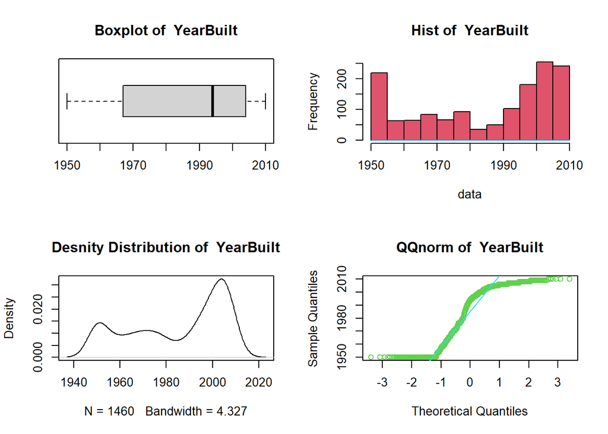

Possiamo notare che la distribuzione ha un pico negli anni 50 con il massimo di rimodellazione nel 1950 con 178 edifici. Dopodichè, si ha un calo quasi immediato e i numeri di edifici rimodellati resta quasi costante fino agli anni 80 dove fra il 1980 al 1985 si nota il minimo numero di rimodellazione. Dopodiche, la distribuzione inizia a crescere quasi costantemente con pico negli anni fra 2000 e 2005

### 5: Visualizazione MasVnrArea

```r
visualization_continuos(na.omit(House_prices[,"MasVnrArea"]), sum_info_h[5],"MasVnrArea")
```

```
## [[1]]
## [[1]]$MasVnrArea
## [[1]]$MasVnrArea$Summary
##    Min. 1st Qu.  Median    Mean 3rd Qu.    Max.
##     0.0     0.0     0.0   103.7   166.0  1600.0
##
## [[1]]$MasVnrArea$Variance
## [1] 32784.97
##
## [[1]]$MasVnrArea$Standard_Deviation
## [1] 181.07
##
## [[1]]$MasVnrArea$Moda
## [[1]]$MasVnrArea$Moda$Mode
## [1] 0
##
## [[1]]$MasVnrArea$Moda$Frequency
## [1] 861
```

```
##
## Call:
##  density.default(x = data)
##
## Data: data (1452 obs.);  Bandwidth 'bw' = 25.99
##
##        x                 y
##  Min.   : -77.98   Min.   :3.000e-09
##  1st Qu.: 361.01   1st Qu.:9.362e-06
##  Median : 800.00   Median :4.165e-05
##  Mean   : 800.00   Mean   :5.685e-04
##  3rd Qu.:1238.99   3rd Qu.:3.960e-04
##  Max.   :1677.98   Max.   :9.300e-03
```

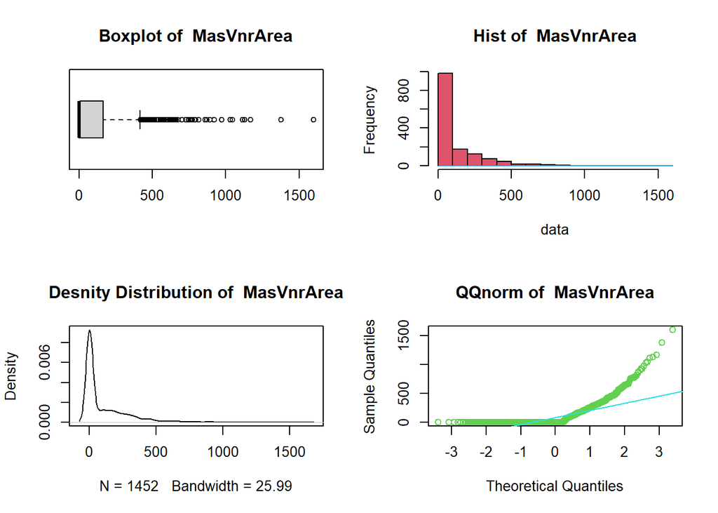

Possiamo dedurre che la distribuzione è positivamente asimetrica. Si puo osservare che l’area di MasVnrArea è prelevantemete 0 qundi non applicato. Per fare un analisi sugli edifici che hanno il Masonry veneer, serve ignorare quelli senza ## Rimozione 0

```r
rm_0_data = rm_0(na.omit(House_prices[,"MasVnrArea"]))
visualization_continuos(rm_0_data, univariate_analysis(rm_0_data,"MasVnrArea"),"MasVnrArea")
```

```
## $MasVnrArea
## $MasVnrArea$Summary
##    Min. 1st Qu.  Median    Mean 3rd Qu.    Max.
##     1.0   113.0   203.0   254.7   330.5  1600.0
##
## $MasVnrArea$Variance
## [1] 42084.13
##
## $MasVnrArea$Standard_Deviation
## [1] 205.14
##
## $MasVnrArea$Moda
## $MasVnrArea$Moda$Mode
## [1] 180 108  72
##
## $MasVnrArea$Moda$Frequency
## [1] 8
```

```
##
## Call:
##  density.default(x = data)
##
## Data: data (591 obs.);   Bandwidth 'bw' = 40.76
##
##        x                y
##  Min.   :-121.3   Min.   :1.888e-07
##  1st Qu.: 339.6   1st Qu.:1.440e-05
##  Median : 800.5   Median :7.853e-05
##  Mean   : 800.5   Mean   :5.419e-04
##  3rd Qu.:1261.4   3rd Qu.:6.832e-04
##  Max.   :1722.3   Max.   :2.868e-03
```

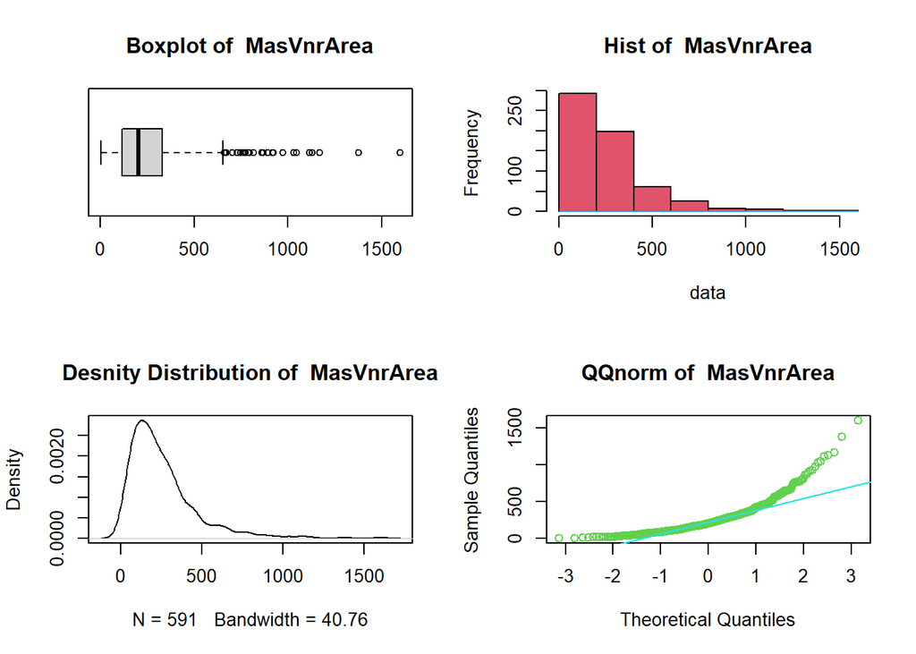

Possiamo dedurre che la distribuzione è positivamente asimetrica e che la maggior parte degli edifici ha un area coperto da Masonry veneer tra 113.0 e 330.5 piedi^2, essendo rispettivamente il 1° e il 3° quantile e con maggior densita alineati alla retta qq della norma. Rimangono ancora degli outlier ## Rimozione

```r
rm_outlier_data = rm_oultiers(rm_0_data,.95)
visualization_continuos(rm_outlier_data, univariate_analysis(rm_outlier_data,"MasVnrArea"),"MasVnrArea")
```

```
## $MasVnrArea
## $MasVnrArea$Summary
##    Min. 1st Qu.  Median    Mean 3rd Qu.    Max.
##     1.0   108.5   192.0   223.0   304.0   653.0
##
## $MasVnrArea$Variance
## [1] 20493.73
##
## $MasVnrArea$Standard_Deviation
## [1] 143.16
##
## $MasVnrArea$Moda
## $MasVnrArea$Moda$Mode
## [1] 180 108  72
##
## $MasVnrArea$Moda$Frequency
## [1] 8
```

```
##
## Call:
##  density.default(x = data)
##
## Data: data (563 obs.);   Bandwidth 'bw' = 36.3
##
##        x                y
##  Min.   :-107.9   Min.   :8.985e-07
##  1st Qu.: 109.5   1st Qu.:2.760e-04
##  Median : 327.0   Median :8.103e-04
##  Mean   : 327.0   Mean   :1.149e-03
##  3rd Qu.: 544.5   3rd Qu.:2.082e-03
##  Max.   : 761.9   Max.   :3.043e-03
```

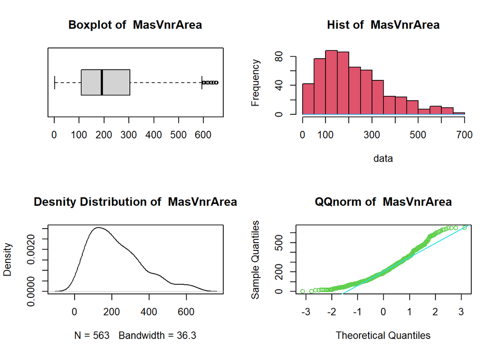

Possiamo dedurre nella distribuzione che la maggior parte degli edifici ha un area coperto da Masonry veneer tra 108.5 e 304.0 piedi^2, essendo rispettivamente il 1° e il 3° quantile e con maggior densita alineati alla retta qq della norma.

### 6: Visualizazione BsmtFinSF1

```r
visualization_continuos(na.omit(House_prices[,"BsmtFinSF1"]), sum_info_h[6],"BsmtFinSF1")
```

```
## [[1]]
## [[1]]$BsmtFinSF1
## [[1]]$BsmtFinSF1$Summary
##    Min. 1st Qu.  Median    Mean 3rd Qu.    Max.
##     0.0     0.0   383.5   443.6   712.2  5644.0
##
## [[1]]$BsmtFinSF1$Variance
## [1] 208025.5
##
## [[1]]$BsmtFinSF1$Standard_Deviation
## [1] 456.1
##
## [[1]]$BsmtFinSF1$Moda
## [[1]]$BsmtFinSF1$Moda$Mode
## [1] 0
##
## [[1]]$BsmtFinSF1$Moda$Frequency
## [1] 467
```

```
##
## Call:
##  density.default(x = data)
##
## Data: data (1460 obs.);  Bandwidth 'bw' = 95.59
##
##        x                y
##  Min.   :-286.8   Min.   :0.000e+00
##  1st Qu.:1267.6   1st Qu.:0.000e+00
##  Median :2822.0   Median :4.431e-07
##  Mean   :2822.0   Mean   :1.606e-04
##  3rd Qu.:4376.4   3rd Qu.:1.658e-04
##  Max.   :5930.8   Max.   :1.525e-03
```

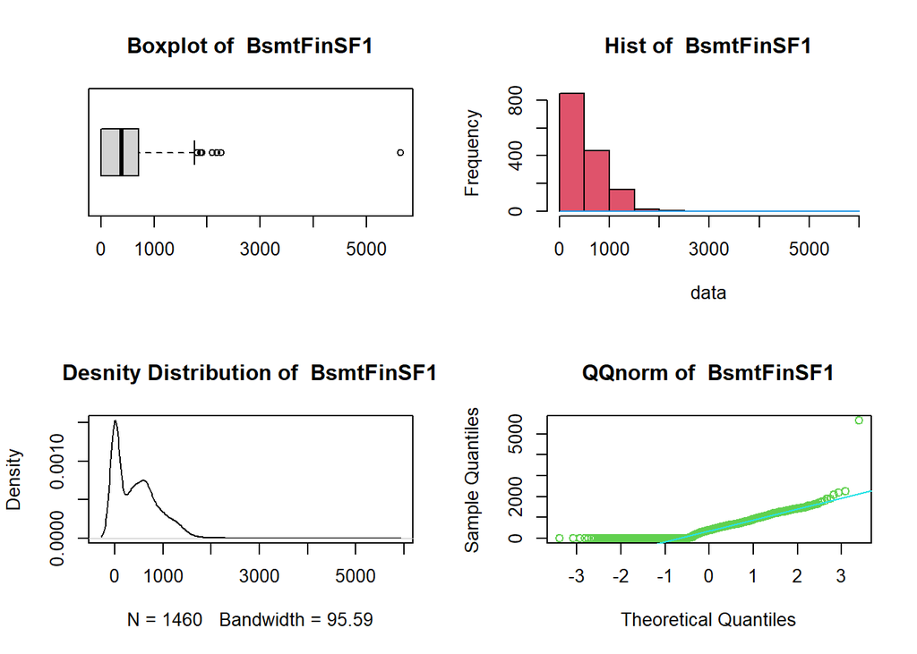

```r
rm_0_data = rm_0(na.omit(House_prices[,"BsmtFinSF1"]))
visualization_continuos(rm_0_data, univariate_analysis(rm_0_data,"BsmtFinSF1"),"BsmtFinSF1")
```

```
## $BsmtFinSF1
## $BsmtFinSF1$Summary
##    Min. 1st Qu.  Median    Mean 3rd Qu.    Max.
##     2.0   371.0   604.0   652.3   867.0  5644.0
##
## $BsmtFinSF1$Variance
## [1] 169727.8
##
## $BsmtFinSF1$Standard_Deviation
## [1] 411.98
##
## $BsmtFinSF1$Moda
## $BsmtFinSF1$Moda$Mode
## [1] 24
##
## $BsmtFinSF1$Moda$Frequency
## [1] 12
```

```
##
## Call:
##  density.default(x = data)
##
## Data: data (993 obs.);   Bandwidth 'bw' = 83.8
##
##        x                y
##  Min.   :-249.4   Min.   :0.000e+00
##  1st Qu.:1286.8   1st Qu.:0.000e+00
##  Median :2823.0   Median :4.138e-07
##  Mean   :2823.0   Mean   :1.626e-04
##  3rd Qu.:4359.2   3rd Qu.:1.431e-04
##  Max.   :5895.4   Max.   :1.121e-03
```

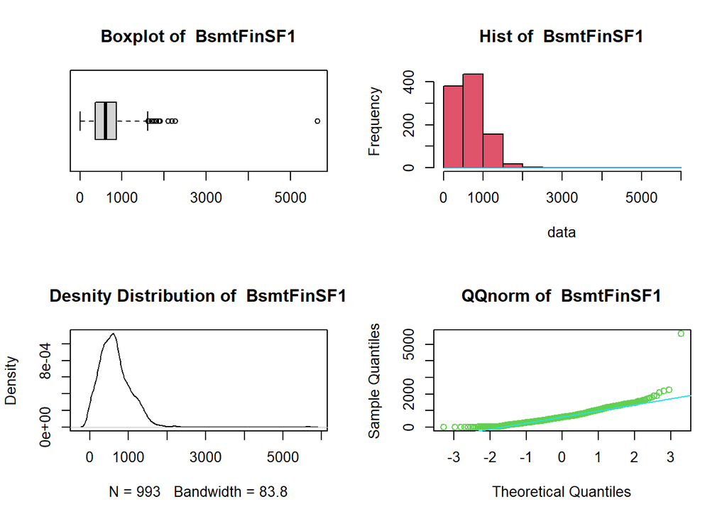

Possiamo dedurre che la distribuzione è positivamente asimetrica e che la maggior parte degli edifici ha un semiterrato finito di tipo 1 di area compresa tra 371.0 e 867.0 piedi^2, essendo rispettivamente il 1° e il 3° quantile e con maggior densita alineati alla retta qq della norma. Rimangono ancora degli outlier ## Rimozione

```r
rm_outlier_data = rm_oultiers(rm_0_data,.95)
visualization_continuos(rm_outlier_data, univariate_analysis(rm_outlier_data,"BsmtFinSF1"),"BsmtFinSF1")
```

```
## $BsmtFinSF1
## $BsmtFinSF1$Summary
##    Min. 1st Qu.  Median    Mean 3rd Qu.    Max.
##     2.0   364.8   594.5   621.4   833.8  1456.0
##
## $BsmtFinSF1$Variance
## [1] 119445.6
##
## $BsmtFinSF1$Standard_Deviation
## [1] 345.61
##
## $BsmtFinSF1$Moda
## $BsmtFinSF1$Moda$Mode
## [1] 24
##
## $BsmtFinSF1$Moda$Frequency
## [1] 12
```

```
##
## Call:
##  density.default(x = data)
##
## Data: data (968 obs.);   Bandwidth 'bw' = 78.64
##
##        x                y
##  Min.   :-233.9   Min.   :4.036e-07
##  1st Qu.: 247.5   1st Qu.:1.898e-04
##  Median : 729.0   Median :4.584e-04
##  Mean   : 729.0   Mean   :5.187e-04
##  3rd Qu.:1210.5   3rd Qu.:8.656e-04
##  Max.   :1691.9   Max.   :1.159e-03
```

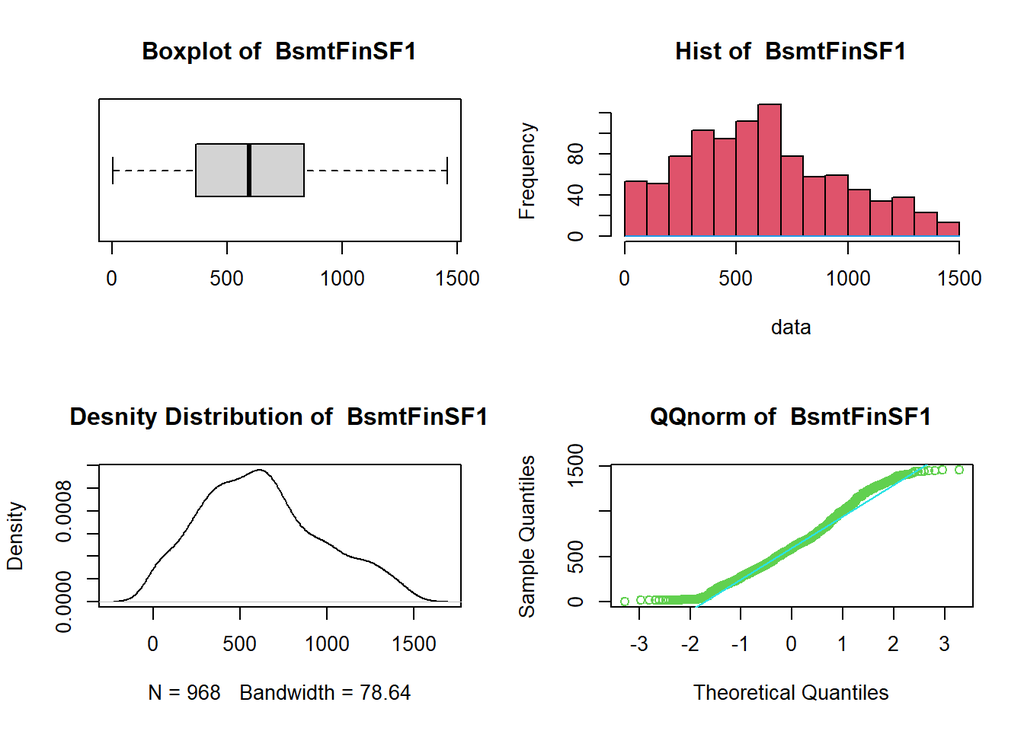

Possiamo dedurre nella distribuzione semi-normato che la maggior parte degli edifici ha un semiterrato finito di tipo 1 di area compresa tra 364.8 e 833.8 piedi^2, essendo rispettivamente il 1° e il 3° quantile e con maggior densita alineati alla retta qq della norma.

### 7: Visualizazione BsmtFinSF2

```r
visualization_continuos(na.omit(House_prices[,"BsmtFinSF2"]), sum_info_h[7],"BsmtFinSF2")
```

```
## [[1]]
## [[1]]$BsmtFinSF2
## [[1]]$BsmtFinSF2$Summary
##    Min. 1st Qu.  Median    Mean 3rd Qu.    Max.
##    0.00    0.00    0.00   46.55    0.00 1474.00
##
## [[1]]$BsmtFinSF2$Variance
## [1] 26023.91
##
## [[1]]$BsmtFinSF2$Standard_Deviation
## [1] 161.32
##
## [[1]]$BsmtFinSF2$Moda
## [[1]]$BsmtFinSF2$Moda$Mode
## [1] 0
##
## [[1]]$BsmtFinSF2$Moda$Frequency
## [1] 1293
```

```
##
## Call:
##  density.default(x = data)
##
## Data: data (1460 obs.);  Bandwidth 'bw' = 33.81
##
##        x                y
##  Min.   :-101.4   Min.   :0.000e+00
##  1st Qu.: 317.8   1st Qu.:1.196e-05
##  Median : 737.0   Median :5.220e-05
##  Mean   : 737.0   Mean   :5.951e-04
##  3rd Qu.:1156.2   3rd Qu.:1.424e-04
##  Max.   :1575.4   Max.   :1.047e-02
```

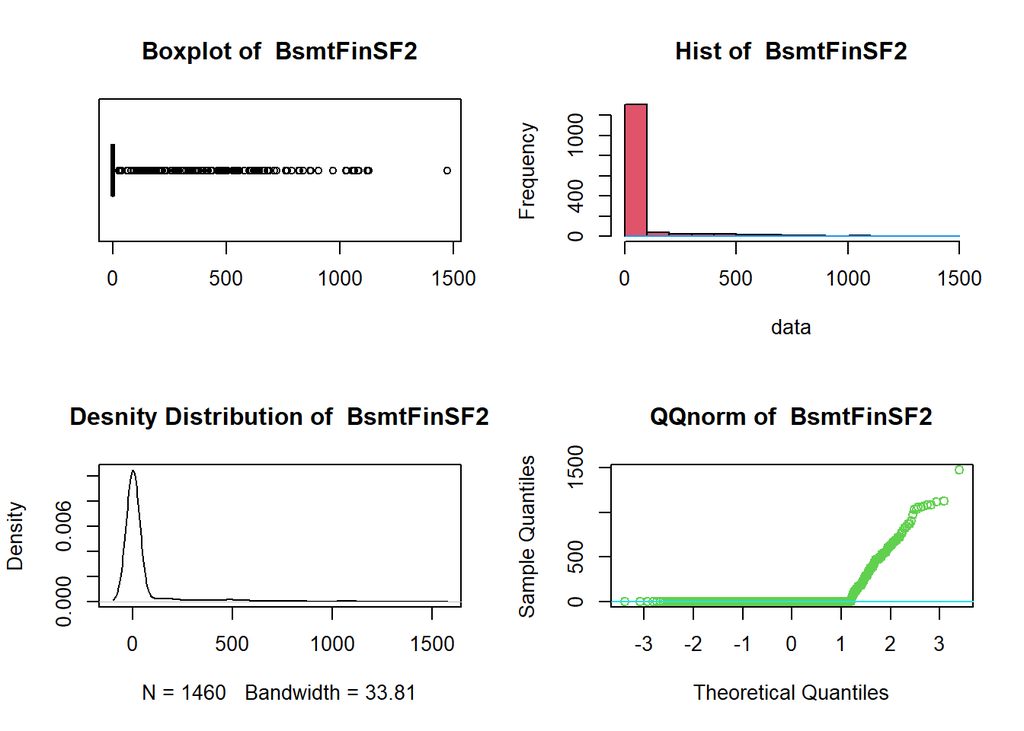

Possiamo dedurre che la distribuzione è positivamente asimetrica. Si puo osservare che l’area finito di semiterrato finito di tipo 2 è prelevantemete 0 qundi non costruitto. Per fare un analisi sugli edifici che hanno il semiterrato finito di tipo 2, serve ignorare quelli senza ## Rimozione 0

```r
rm_0_data = rm_0(na.omit(House_prices[,"BsmtFinSF2"]))
visualization_continuos(rm_0_data, univariate_analysis(rm_0_data,"BsmtFinSF2"),"BsmtFinSF2")
```

```
## $BsmtFinSF2
## $BsmtFinSF2$Summary
##    Min. 1st Qu.  Median    Mean 3rd Qu.    Max.
##    28.0   178.5   354.0   407.0   551.0  1474.0
##
## $BsmtFinSF2$Variance
## [1] 81173.38
##
## $BsmtFinSF2$Standard_Deviation
## [1] 284.91
##
## $BsmtFinSF2$Moda
## $BsmtFinSF2$Moda$Mode
## [1] 180
##
## $BsmtFinSF2$Moda$Frequency
## [1] 5
```

```
##
## Call:
##  density.default(x = data)
##
## Data: data (167 obs.);   Bandwidth 'bw' = 89.89
##
##        x                y
##  Min.   :-241.7   Min.   :2.985e-07
##  1st Qu.: 254.7   1st Qu.:2.557e-05
##  Median : 751.0   Median :2.538e-04
##  Mean   : 751.0   Mean   :5.032e-04
##  3rd Qu.:1247.3   3rd Qu.:1.001e-03
##  Max.   :1743.7   Max.   :1.592e-03
```

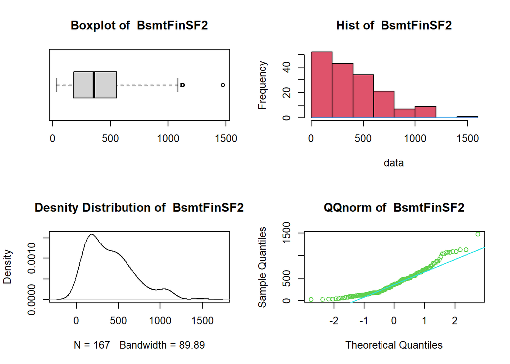

Possiamo dedurre che la distribuzione è positivamente asimetrica e che la maggior parte degli edifici ha un semiterrato finito di tipo 2 di area compresa tra 178.5 e 551.0 piedi^2, essendo rispettivamente il 1° e il 3° quantile e con maggior densita alineati alla retta qq della norma. Rimangono ancora degli outlier ## Rimozione

```r
rm_outlier_data = rm_oultiers(rm_0_data,.95)
visualization_continuos(rm_outlier_data, univariate_analysis(rm_outlier_data,"BsmtFinSF2"),"BsmtFinSF2")
```

```
## $BsmtFinSF2
## $BsmtFinSF2$Summary
##    Min. 1st Qu.  Median    Mean 3rd Qu.    Max.
##    28.0   173.8   329.0   358.1   512.2   906.0
##
## $BsmtFinSF2$Variance
## [1] 49340.55
##
## $BsmtFinSF2$Standard_Deviation
## [1] 222.13
##
## $BsmtFinSF2$Moda
## $BsmtFinSF2$Moda$Mode
## [1] 180
##
## $BsmtFinSF2$Moda$Frequency
## [1] 5
```

```
##
## Call:
##  density.default(x = data)
##
## Data: data (156 obs.);   Bandwidth 'bw' = 72.81
##
##        x                y
##  Min.   :-190.4   Min.   :5.917e-07
##  1st Qu.: 138.3   1st Qu.:1.521e-04
##  Median : 467.0   Median :7.180e-04
##  Mean   : 467.0   Mean   :7.597e-04
##  3rd Qu.: 795.7   3rd Qu.:1.262e-03
##  Max.   :1124.4   Max.   :1.840e-03
```

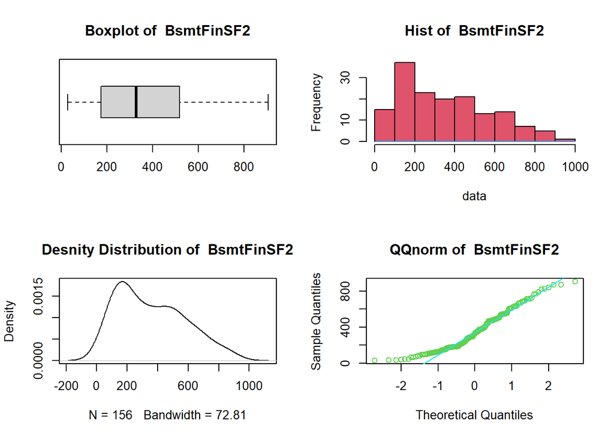

Possiamo dedurre nella distribuzione semi-normato che la maggior parte degli edifici ha un semiterrato finito di tipo 2 di area compresa tra 173.8 e 512.2 piedi^2, essendo rispettivamente il 1° e il 3° quantile e con maggior densita alineati alla retta qq della norma.

### 8: Visualizazione BsmtUnfSF

```r
visualization_continuos(na.omit(House_prices[,"BsmtUnfSF"]), sum_info_h[8],"BsmtUnfSF")
```

```
## [[1]]
## [[1]]$BsmtUnfSF
## [[1]]$BsmtUnfSF$Summary
##    Min. 1st Qu.  Median    Mean 3rd Qu.    Max.
##     0.0   223.0   477.5   567.2   808.0  2336.0
##
## [[1]]$BsmtUnfSF$Variance
## [1] 195246.4
##
## [[1]]$BsmtUnfSF$Standard_Deviation
## [1] 441.87
##
## [[1]]$BsmtUnfSF$Moda
## [[1]]$BsmtUnfSF$Moda$Mode
## [1] 0
##
## [[1]]$BsmtUnfSF$Moda$Frequency
## [1] 118
```

```
##
## Call:
##  density.default(x = data)
##
## Data: data (1460 obs.);  Bandwidth 'bw' = 91.5
##
##        x                y
##  Min.   :-274.5   Min.   :3.380e-08
##  1st Qu.: 446.7   1st Qu.:2.885e-05
##  Median :1168.0   Median :2.109e-04
##  Mean   :1168.0   Mean   :3.462e-04
##  3rd Qu.:1889.3   3rd Qu.:7.062e-04
##  Max.   :2610.5   Max.   :9.942e-04
```

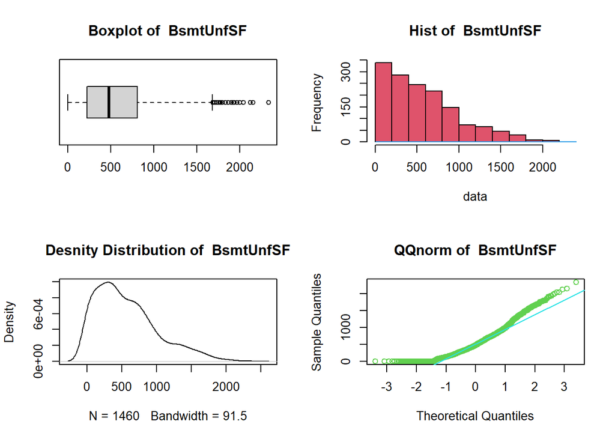

```r
rm_0_data = rm_0(na.omit(House_prices[,"BsmtUnfSF"]))
visualization_continuos(rm_0_data, univariate_analysis(rm_0_data,"BsmtUnfSF"),"BsmtUnfSF")
```

```
## $BsmtUnfSF
## $BsmtUnfSF$Summary
##    Min. 1st Qu.  Median    Mean 3rd Qu.    Max.
##    14.0   288.0   536.0   617.1   843.2  2336.0
##
## $BsmtUnfSF$Variance
## [1] 181624.3
##
## $BsmtUnfSF$Standard_Deviation
## [1] 426.17
##
## $BsmtUnfSF$Moda
## $BsmtUnfSF$Moda$Mode
## [1] 728
##
## $BsmtUnfSF$Moda$Frequency
## [1] 9
```

```
##
## Call:
##  density.default(x = data)
##
## Data: data (1342 obs.);  Bandwidth 'bw' = 88.32
##
##        x              y
##  Min.   :-251   Min.   :3.810e-08
##  1st Qu.: 462   1st Qu.:2.536e-05
##  Median :1175   Median :2.098e-04
##  Mean   :1175   Mean   :3.503e-04
##  3rd Qu.:1888   3rd Qu.:7.008e-04
##  Max.   :2601   Max.   :1.084e-03
```

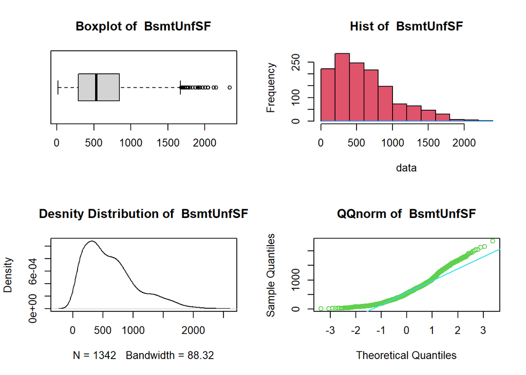

Possiamo dedurre che la distribuzione è positivamente asimetrica e che la maggior parte degli edifici ha un semiterrato non finito di area compresa tra 288.0 e 843.2 piedi^2, essendo rispettivamente il 1° e il 3° quantile e con maggior densita alineati alla retta qq della norma. Rimangono ancora degli outlier ## Rimozione

```r
rm_outlier_data = rm_oultiers(rm_0_data,.95)
visualization_continuos(rm_outlier_data, univariate_analysis(rm_outlier_data,"BsmtUnfSF"),"BsmtUnfSF")
```

```
## $BsmtUnfSF
## $BsmtUnfSF$Summary
##    Min. 1st Qu.  Median    Mean 3rd Qu.    Max.
##    14.0   278.5   495.0   554.4   780.0  1450.0
##
## $BsmtUnfSF$Variance
## [1] 120004.2
##
## $BsmtUnfSF$Standard_Deviation
## [1] 346.42
##
## $BsmtUnfSF$Moda
## $BsmtUnfSF$Moda$Mode
## [1] 728
##
## $BsmtUnfSF$Moda$Frequency
## [1] 9
```

```
##
## Call:
##  density.default(x = data)
##
## Data: data (1267 obs.);  Bandwidth 'bw' = 74.69
##
##        x                y
##  Min.   :-210.1   Min.   :2.806e-07
##  1st Qu.: 261.0   1st Qu.:1.939e-04
##  Median : 732.0   Median :4.555e-04
##  Mean   : 732.0   Mean   :5.302e-04
##  3rd Qu.:1203.0   3rd Qu.:8.862e-04
##  Max.   :1674.1   Max.   :1.164e-03
```

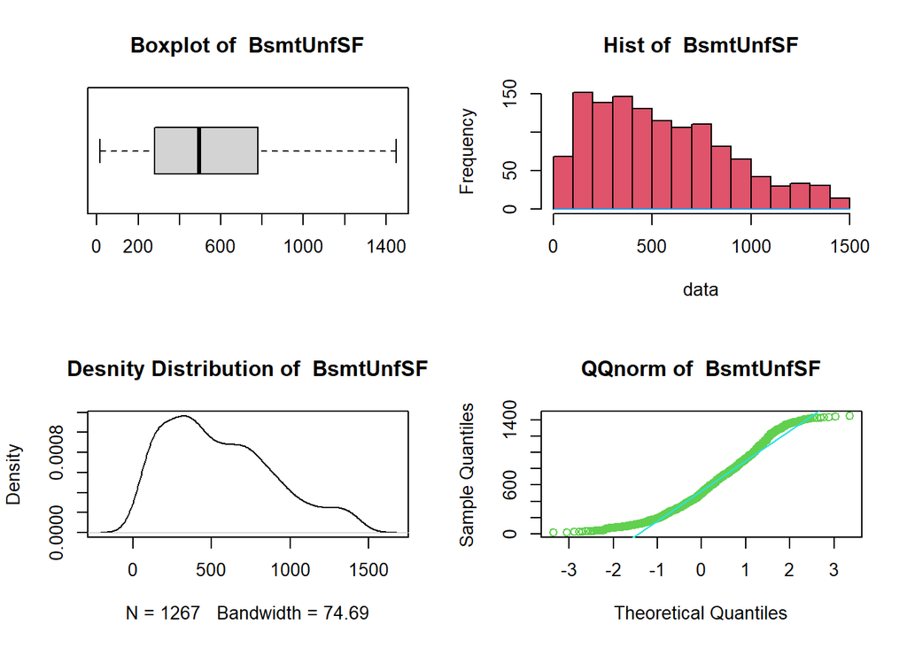

Possiamo dedurre nella distribuzione semi-normato che la maggior parte degli edifici ha un semiterrato non finito di area compresa tra 278.5 e 780.0 piedi^2, essendo rispettivamente il 1° e il 3° quantile e con maggior densita alineati alla retta qq della norma.

### 9: Visualizazione TotalBsmtSF

```r
visualization_continuos(na.omit(House_prices[,"TotalBsmtSF"]), sum_info_h[9],"TotalBsmtSF")
```

```
## [[1]]
## [[1]]$TotalBsmtSF
## [[1]]$TotalBsmtSF$Summary
##    Min. 1st Qu.  Median    Mean 3rd Qu.    Max.
##     0.0   795.8   991.5  1057.4  1298.2  6110.0
##
## [[1]]$TotalBsmtSF$Variance
## [1] 192462.4
##
## [[1]]$TotalBsmtSF$Standard_Deviation
## [1] 438.71
##
## [[1]]$TotalBsmtSF$Moda
## [[1]]$TotalBsmtSF$Moda$Mode
## [1] 0
##
## [[1]]$TotalBsmtSF$Moda$Frequency
## [1] 37
```

```
##
## Call:
##  density.default(x = data)
##
## Data: data (1460 obs.);  Bandwidth 'bw' = 78.6
##
##        x                y
##  Min.   :-235.8   Min.   :0.000e+00
##  1st Qu.:1409.6   1st Qu.:0.000e+00
##  Median :3055.0   Median :3.073e-06
##  Mean   :3055.0   Mean   :1.518e-04
##  3rd Qu.:4700.4   3rd Qu.:1.024e-04
##  Max.   :6345.8   Max.   :1.254e-03
```

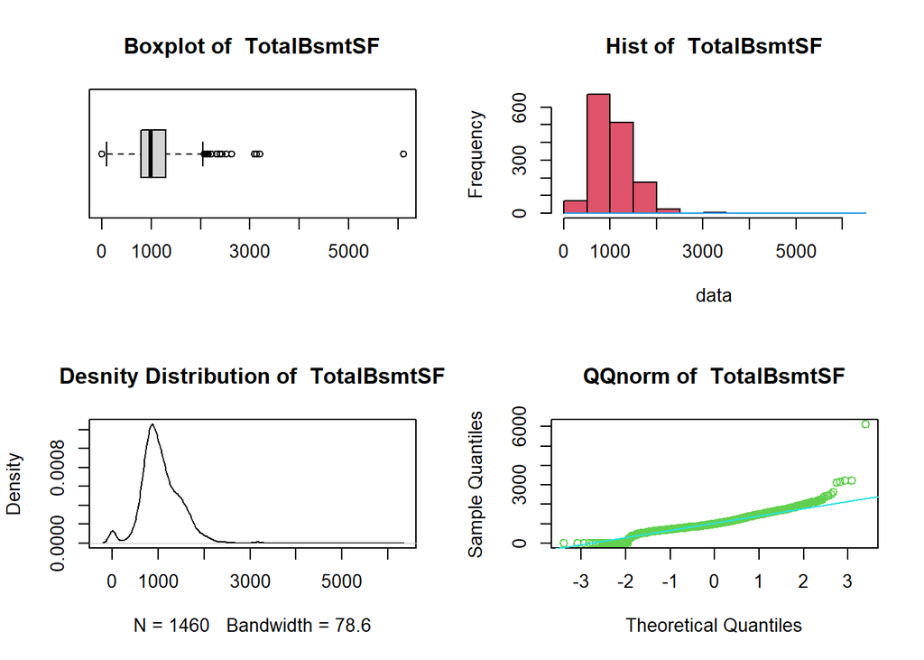

```r
rm_0_data = rm_0(na.omit(House_prices[,"TotalBsmtSF"]))
visualization_continuos(rm_0_data, univariate_analysis(rm_0_data,"TotalBsmtSF"),"TotalBsmtSF")
```

```
## $TotalBsmtSF
## $TotalBsmtSF$Summary
##    Min. 1st Qu.  Median    Mean 3rd Qu.    Max.
##   105.0   810.5  1004.0  1084.9  1309.5  6110.0
##
## $TotalBsmtSF$Variance
## [1] 167619.6
##
## $TotalBsmtSF$Standard_Deviation
## [1] 409.41
##
## $TotalBsmtSF$Moda
## $TotalBsmtSF$Moda$Mode
## [1] 864
##
## $TotalBsmtSF$Moda$Frequency
## [1] 35
```

```
##
## Call:
##  density.default(x = data)
##
## Data: data (1423 obs.);  Bandwidth 'bw' = 78.45
##
##        x                y
##  Min.   :-130.4   Min.   :0.000e+00
##  1st Qu.:1488.6   1st Qu.:0.000e+00
##  Median :3107.5   Median :2.040e-06
##  Mean   :3107.5   Mean   :1.543e-04
##  3rd Qu.:4726.4   3rd Qu.:8.769e-05
##  Max.   :6345.4   Max.   :1.287e-03
```

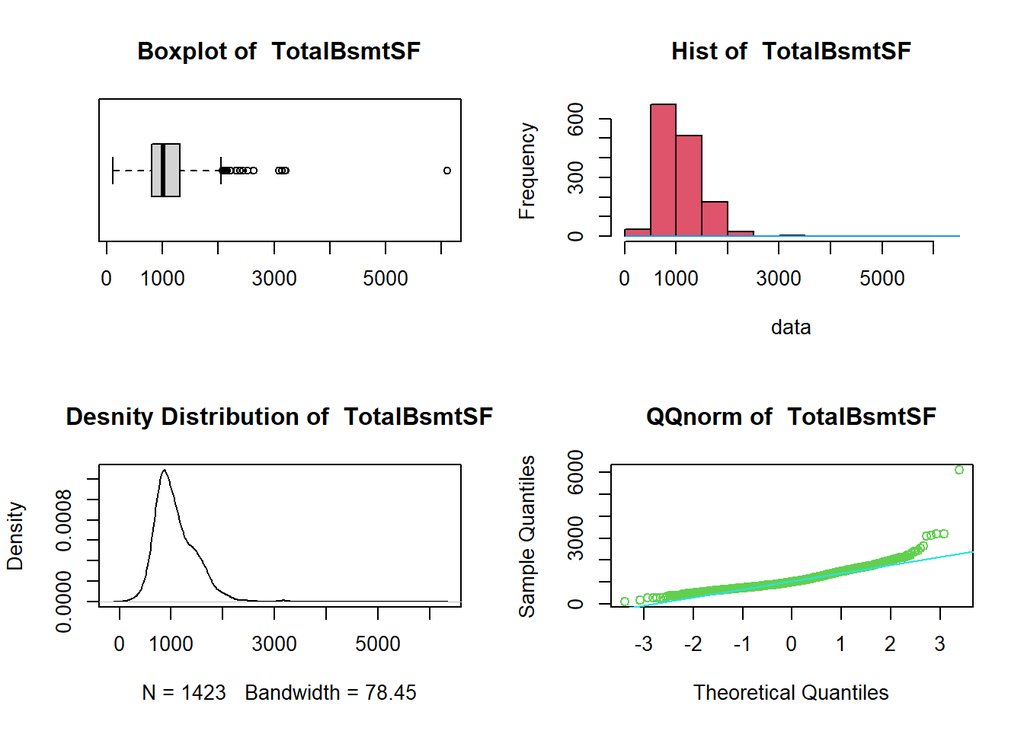

Possiamo dedurre che la distribuzione è positivamente asimetrica e che la maggior parte degli edifici ha un semiterrato di area compresa tra 810.5 e 1309.5 piedi^2, essendo rispettivamente il 1° e il 3° quantile e con maggior densita alineati alla retta qq della norma. Rimangono ancora degli outlier ## Rimozione

```r
rm_outlier_data = rm_oultiers(rm_0_data,.95)
visualization_continuos(rm_outlier_data, univariate_analysis(rm_outlier_data,"TotalBsmtSF"),"TotalBsmtSF")
```

```
## $TotalBsmtSF
## $TotalBsmtSF$Summary
##    Min. 1st Qu.  Median    Mean 3rd Qu.    Max.
##   290.0   806.0   990.5  1048.2  1264.0  1869.0
##
## $TotalBsmtSF$Variance
## [1] 106622.3
##
## $TotalBsmtSF$Standard_Deviation
## [1] 326.53
##
## $TotalBsmtSF$Moda
## $TotalBsmtSF$Moda$Mode
## [1] 864
##
## $TotalBsmtSF$Moda$Frequency
## [1] 35
```

```
##
## Call:
##  density.default(x = data)
##
## Data: data (1370 obs.);  Bandwidth 'bw' = 69.31
##
##        x                 y
##  Min.   :  82.06   Min.   :6.440e-08
##  1st Qu.: 580.78   1st Qu.:8.634e-05
##  Median :1079.50   Median :4.377e-04
##  Mean   :1079.50   Mean   :5.008e-04
##  3rd Qu.:1578.22   3rd Qu.:8.098e-04
##  Max.   :2076.94   Max.   :1.364e-03
```

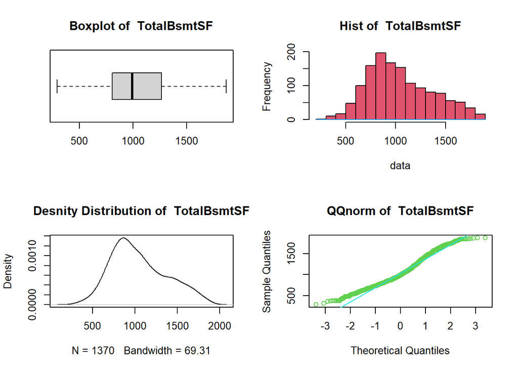

### 10: Visualizazione X1stFlrSF

```r
visualization_continuos(na.omit(House_prices[,"X1stFlrSF"]), sum_info_h[10],"X1stFlrSF")
```

```
## [[1]]
## [[1]]$X1stFlrSF
## [[1]]$X1stFlrSF$Summary
##    Min. 1st Qu.  Median    Mean 3rd Qu.    Max.
##     334     882    1087    1163    1391    4692
##
## [[1]]$X1stFlrSF$Variance
## [1] 149450.1
##
## [[1]]$X1stFlrSF$Standard_Deviation
## [1] 386.59
##
## [[1]]$X1stFlrSF$Moda
## [[1]]$X1stFlrSF$Moda$Mode
## [1] 864
##
## [[1]]$X1stFlrSF$Moda$Frequency
## [1] 25
```

```
##
## Call:
##  density.default(x = data)
##
## Data: data (1460 obs.);  Bandwidth 'bw' = 79.65
##
##        x                 y
##  Min.   :  95.04   Min.   :0.000e+00
##  1st Qu.:1304.02   1st Qu.:2.549e-07
##  Median :2513.00   Median :5.676e-06
##  Mean   :2513.00   Mean   :2.066e-04
##  3rd Qu.:3721.98   3rd Qu.:2.578e-04
##  Max.   :4930.96   Max.   :1.237e-03
```

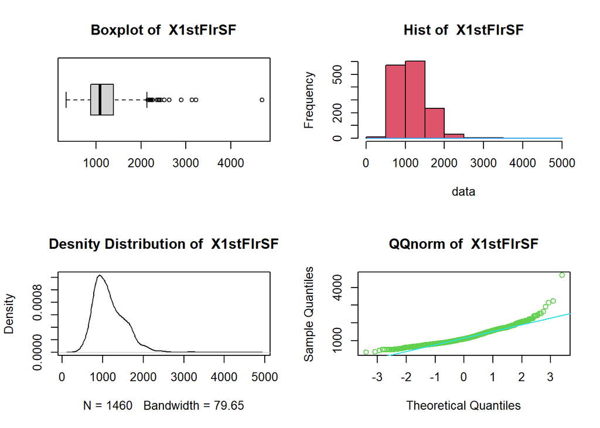

Possiamo dedurre che la distribuzione è positivamente asimetrica e che la maggior parte degli edifici ha il primo piano di area compresa tra 882 e 1391 piedi^2, essendo rispettivamente il 1° e il 3° quantile e con maggior densita alineati alla retta qq della norma. Rimangono ancora degli outlier ## Rimozione

```r
rm_outlier_data = rm_oultiers(House_prices[,"X1stFlrSF"],.95)
visualization_continuos(rm_outlier_data, univariate_analysis(rm_outlier_data,"X1stFlrSF"),"X1stFlrSF")
```

```
## $X1stFlrSF
## $X1stFlrSF$Summary
##    Min. 1st Qu.  Median    Mean 3rd Qu.    Max.
##     438     874    1072    1122    1344    1905
##
## $X1stFlrSF$Variance
## [1] 101485.5
##
## $X1stFlrSF$Standard_Deviation
## [1] 318.57
##
## $X1stFlrSF$Moda
## $X1stFlrSF$Moda$Mode
## [1] 864
##
## $X1stFlrSF$Moda$Frequency
## [1] 25
```

```
##
## Call:
##  density.default(x = data)
##
## Data: data (1403 obs.);  Bandwidth 'bw' = 67.3
##
##        x                y
##  Min.   : 236.1   Min.   :9.690e-08
##  1st Qu.: 703.8   1st Qu.:1.096e-04
##  Median :1171.5   Median :5.082e-04
##  Mean   :1171.5   Mean   :5.340e-04
##  3rd Qu.:1639.2   3rd Qu.:8.647e-04
##  Max.   :2106.9   Max.   :1.313e-03
```

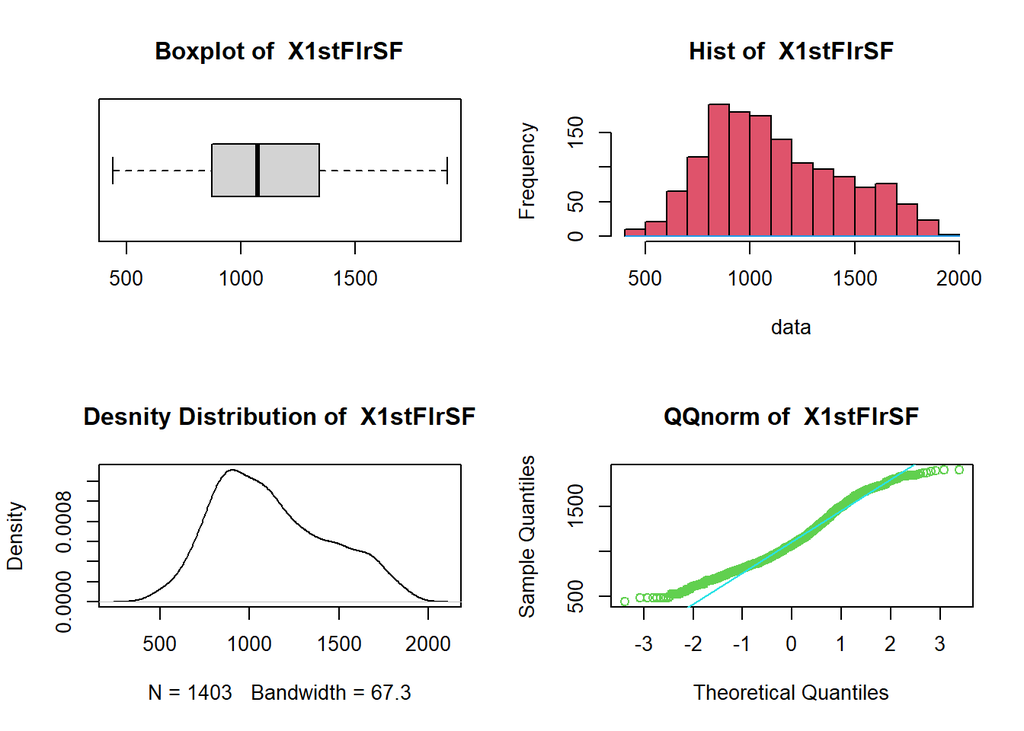

Possiamo notare che la maggior parte degli edifici ha il primo piano di area compresa tra 874 e 1344 piedi^2, essendo rispettivamente il 1° e il 3° quantile e con maggior densita alineati alla retta qq della norma.

### 11: Visualizazione X2ndFlrSF

```r
visualization_continuos(na.omit(House_prices[,"X2ndFlrSF"]), sum_info_h[11],"X2ndFlrSF")
```

```
## [[1]]
## [[1]]$X2ndFlrSF
## [[1]]$X2ndFlrSF$Summary
##    Min. 1st Qu.  Median    Mean 3rd Qu.    Max.
##       0       0       0     347     728    2065
##
## [[1]]$X2ndFlrSF$Variance
## [1] 190557.1
##
## [[1]]$X2ndFlrSF$Standard_Deviation
## [1] 436.53
##
## [[1]]$X2ndFlrSF$Moda
## [[1]]$X2ndFlrSF$Moda$Mode
## [1] 0
##
## [[1]]$X2ndFlrSF$Moda$Frequency
## [1] 829
```

```
##
## Call:
##  density.default(x = data)
##
## Data: data (1460 obs.);  Bandwidth 'bw' = 91.49
##
##        x                y
##  Min.   :-274.5   Min.   :3.360e-08
##  1st Qu.: 379.0   1st Qu.:1.064e-05
##  Median :1032.5   Median :1.700e-04
##  Mean   :1032.5   Mean   :3.819e-04
##  3rd Qu.:1686.0   3rd Qu.:5.216e-04
##  Max.   :2339.5   Max.   :2.478e-03
```

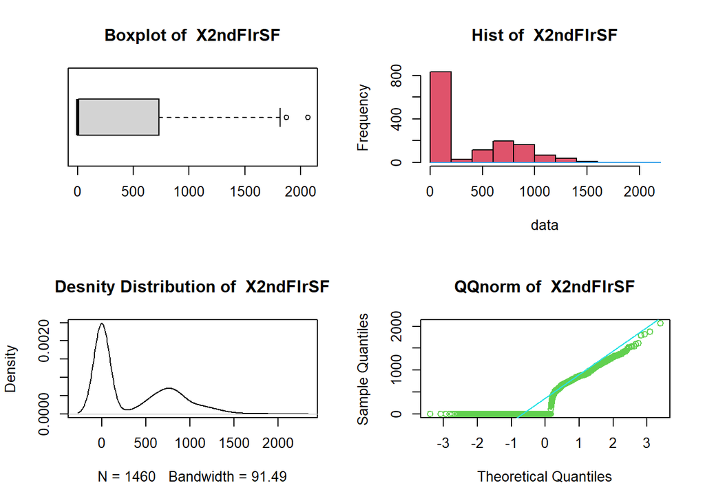

Possiamo dedurre che la distribuzione è positivamente asimetrica. Si puo osservare che l’area del secondo piano è prelevantemete 0 qundi non costruitto. Per fare un analisi sugli edifici che hanno il secondo piano, serve ignorare quelli senza ## Rimozione 0

```r
rm_0_data = rm_0(na.omit(House_prices[,"X2ndFlrSF"]))
visualization_continuos(rm_0_data, univariate_analysis(rm_0_data,"X2ndFlrSF"),"X2ndFlrSF")
```

```
## $X2ndFlrSF
## $X2ndFlrSF$Summary
##    Min. 1st Qu.  Median    Mean 3rd Qu.    Max.
##   110.0   625.0   776.0   802.9   926.5  2065.0
##
## $X2ndFlrSF$Variance
## [1] 74718.56
##
## $X2ndFlrSF$Standard_Deviation
## [1] 273.35
##
## $X2ndFlrSF$Moda
## $X2ndFlrSF$Moda$Mode
## [1] 728
##
## $X2ndFlrSF$Moda$Frequency
## [1] 10
```

```
##
## Call:
##  density.default(x = data)
##
## Data: data (631 obs.);   Bandwidth 'bw' = 55.77
##
##        x                 y
##  Min.   : -57.32   Min.   :1.284e-07
##  1st Qu.: 515.09   1st Qu.:1.705e-05
##  Median :1087.50   Median :1.611e-04
##  Mean   :1087.50   Mean   :4.363e-04
##  3rd Qu.:1659.91   3rd Qu.:6.302e-04
##  Max.   :2232.32   Max.   :1.738e-03
```

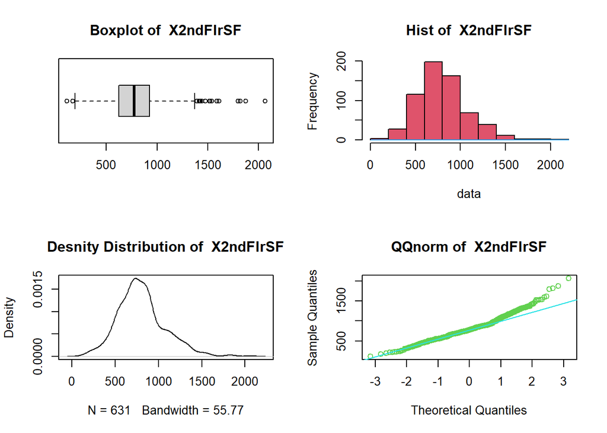

Possiamo dedurre che la distribuzione è positivamente asimetrica e che la maggior parte degli edifici ha il secondo piano di area compresa tra 625.0 e 926.5 piedi^2, essendo rispettivamente il 1° e il 3° quantile e con maggior densita alineati alla retta qq della norma. Rimangono ancora degli outlier ## Rimozione

```r
rm_outlier_data = rm_oultiers(rm_0_data,.90)
visualization_continuos(rm_outlier_data, univariate_analysis(rm_outlier_data,"X2ndFlrSF"),"X2ndFlrSF")
```

```
## $X2ndFlrSF
## $X2ndFlrSF$Summary
##    Min. 1st Qu.  Median    Mean 3rd Qu.    Max.
##     358     634     762     776     895    1243
##
## $X2ndFlrSF$Variance
## [1] 39522.8
##
## $X2ndFlrSF$Standard_Deviation
## [1] 198.8
##
## $X2ndFlrSF$Moda
## $X2ndFlrSF$Moda$Mode
## [1] 728
##
## $X2ndFlrSF$Moda$Frequency
## [1] 10
```

```
##
## Call:
##  density.default(x = data)
##
## Data: data (565 obs.);   Bandwidth 'bw' = 49.36
##
##        x                y
##  Min.   : 209.9   Min.   :5.443e-07
##  1st Qu.: 505.2   1st Qu.:2.248e-04
##  Median : 800.5   Median :6.737e-04
##  Mean   : 800.5   Mean   :8.458e-04
##  3rd Qu.:1095.8   3rd Qu.:1.437e-03
##  Max.   :1391.1   Max.   :1.975e-03
```

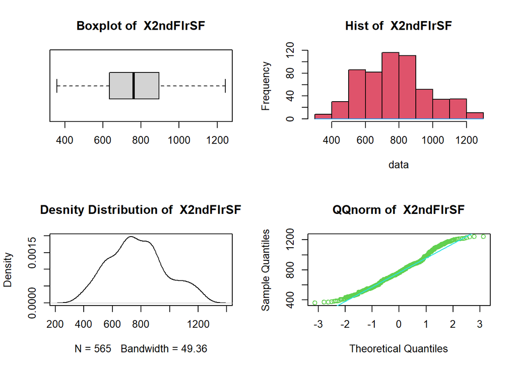

Possiamo notare che la maggior parte degli edifici ha il secondo piano di area compresa tra 634 e 895 piedi^2, essendo rispettivamente il 1° e il 3° quantile e con maggior densita alineati alla retta qq della norma.

### 12: Visualizazione LowQualFinSF

```r
visualization_continuos(na.omit(House_prices[,"LowQualFinSF"]), sum_info_h[12],"LowQualFinSF")
```

```
## [[1]]
## [[1]]$LowQualFinSF
## [[1]]$LowQualFinSF$Summary
##    Min. 1st Qu.  Median    Mean 3rd Qu.    Max.
##   0.000   0.000   0.000   5.845   0.000 572.000
##
## [[1]]$LowQualFinSF$Variance
## [1] 2364.2
##
## [[1]]$LowQualFinSF$Standard_Deviation
## [1] 48.62
##
## [[1]]$LowQualFinSF$Moda
## [[1]]$LowQualFinSF$Moda$Mode
## [1] 0
##
## [[1]]$LowQualFinSF$Moda$Frequency
## [1] 1434
```

```
##
## Call:
##  density.default(x = data)
##
## Data: data (1460 obs.);  Bandwidth 'bw' = 10.19
##
##        x                y
##  Min.   :-30.57   Min.   :0.000e+00
##  1st Qu.:127.71   1st Qu.:9.700e-06
##  Median :286.00   Median :2.900e-05
##  Mean   :286.00   Mean   :1.576e-03
##  3rd Qu.:444.29   3rd Qu.:6.513e-05
##  Max.   :602.57   Max.   :3.834e-02
```

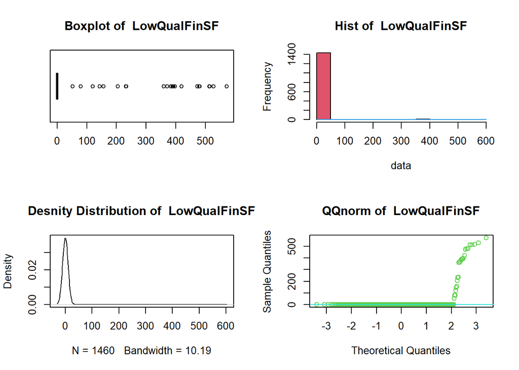

Possiamo dedurre che la distribuzione è positivamente asimetrica. Si puo osservare che l’area dei piani fatti male è prelevantemete 0 Per fare un analisi sugli edifici che hanno i piani fatti male, serve ignorare quelli senza ## Rimozione 0

```r
rm_0_data = rm_0(na.omit(House_prices[,"LowQualFinSF"]))
visualization_continuos(rm_0_data, univariate_analysis(rm_0_data,"LowQualFinSF"),"LowQualFinSF")
```

```
## $LowQualFinSF
## $LowQualFinSF$Summary
##    Min. 1st Qu.  Median    Mean 3rd Qu.    Max.
##    53.0   168.2   377.5   328.2   477.5   572.0
##
## $LowQualFinSF$Variance
## [1] 27951.2
##
## $LowQualFinSF$Standard_Deviation
## [1] 167.19
##
## $LowQualFinSF$Moda
## $LowQualFinSF$Moda$Mode
## [1] 80
##
## $LowQualFinSF$Moda$Frequency
## [1] 3
```

```
##
## Call:
##  density.default(x = data)
##
## Data: data (26 obs.);    Bandwidth 'bw' = 78.42
##
##        x                 y
##  Min.   :-182.27   Min.   :3.188e-06
##  1st Qu.:  65.11   1st Qu.:1.957e-04
##  Median : 312.50   Median :1.231e-03
##  Mean   : 312.50   Mean   :1.009e-03
##  3rd Qu.: 559.89   3rd Qu.:1.471e-03
##  Max.   : 807.27   Max.   :2.264e-03
```

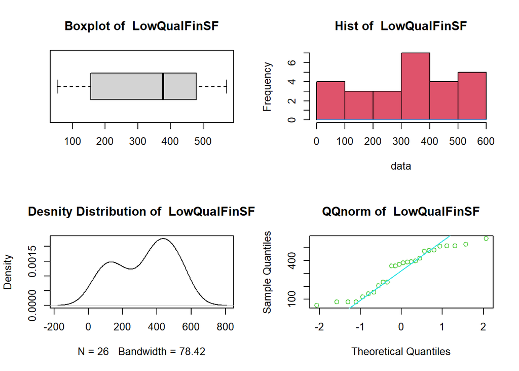

### 13: Visualizazione GrLivArea

```r
visualization_continuos(na.omit(House_prices[,"GrLivArea"]), sum_info_h[13],"GrLivArea")
```

```
## [[1]]
## [[1]]$GrLivArea
## [[1]]$GrLivArea$Summary
##    Min. 1st Qu.  Median    Mean 3rd Qu.    Max.
##     334    1130    1464    1515    1777    5642
##
## [[1]]$GrLivArea$Variance
## [1] 276129.6
##
## [[1]]$GrLivArea$Standard_Deviation
## [1] 525.48
##
## [[1]]$GrLivArea$Moda
## [[1]]$GrLivArea$Moda$Mode
## [1] 864
##
## [[1]]$GrLivArea$Moda$Frequency
## [1] 22
```

```
##
## Call:
##  density.default(x = data)
##
## Data: data (1460 obs.);  Bandwidth 'bw' = 101.2
##
##        x                 y
##  Min.   :  30.29   Min.   :1.000e-10
##  1st Qu.:1509.14   1st Qu.:1.295e-06
##  Median :2988.00   Median :1.176e-05
##  Mean   :2988.00   Mean   :1.689e-04
##  3rd Qu.:4466.85   3rd Qu.:2.169e-04
##  Max.   :5945.71   Max.   :8.045e-04
```

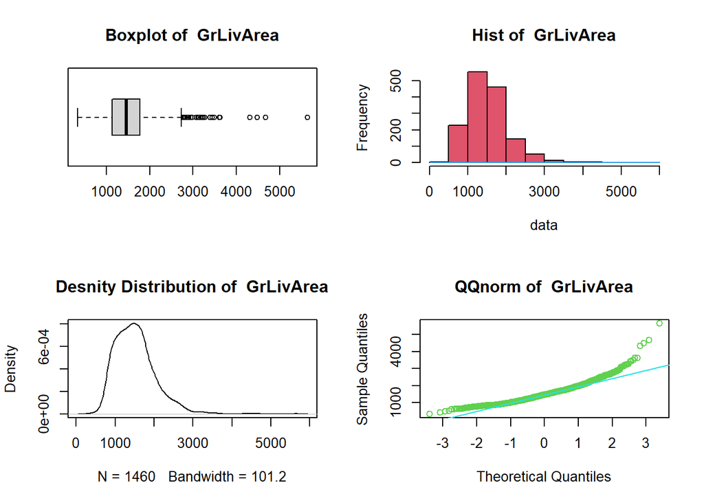

Possiamo dedurre che la distribuzione è positivamente asimetrica e che la maggior parte degli edifici che sono sopra il seminterrato sono di area compresa tra 1130 e 1777 piedi^2, essendo rispettivamente il 1° e il 3° quantile e con maggior densita alineati alla retta qq della norma. Rimangono ancora degli outlier ## Rimozione

```r
rm_outlier_data = rm_oultiers(na.omit(House_prices[,"GrLivArea"]),.95)
visualization_continuos(rm_outlier_data, univariate_analysis(rm_outlier_data,"GrLivArea"),"GrLivArea")
```

```
## $GrLivArea
## $GrLivArea$Summary
##    Min. 1st Qu.  Median    Mean 3rd Qu.    Max.
##     520    1121    1440    1456    1728    2531
##
## $GrLivArea$Variance
## [1] 176895.8
##
## $GrLivArea$Standard_Deviation
## [1] 420.59
##
## $GrLivArea$Moda
## $GrLivArea$Moda$Mode
## [1] 864
##
## $GrLivArea$Moda$Frequency
## [1] 22
```

```
##
## Call:
##  density.default(x = data)
##
## Data: data (1398 obs.);  Bandwidth 'bw' = 88.92
##
##        x                y
##  Min.   : 253.2   Min.   :4.100e-08
##  1st Qu.: 889.4   1st Qu.:7.707e-05
##  Median :1525.5   Median :3.389e-04
##  Mean   :1525.5   Mean   :3.926e-04
##  3rd Qu.:2161.6   3rd Qu.:7.425e-04
##  Max.   :2797.8   Max.   :8.456e-04
```

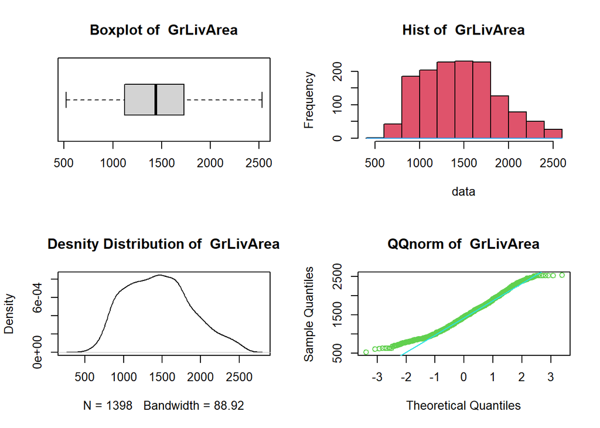

Possiamo notare che la maggior parte degli edifici che sono sopra il seminterrato sono compresi tra 1121 e 1728 piedi^2, essendo rispettivamente il 1° e il 3° quantile e con maggior densita alineati alla retta qq della norma.